# QTM 151 - Quiz 2

## Try to submit as an HTML file

Print your name below

```python
# Write your answer here

print("Neha Murthy")
```

```
Neha Murthy
```

This quiz is open book

- You can use the lecture notes
- You will get partial credit for attempting the questions
- To get full credit, the code should run as intended
- You should NOT communicate with other students

Print the following message:

"I will abide by Emory's code of conduct"

```python
# Write your answer here:

print("I will abide by Emory's code of conduct.")
```

```
I will abide by Emory's code of conduct.
```

Import the libraries "numpy", "matplotlib.pyplot", and "pandas"

```python
# Write your answer here

import numpy as np
import matplotlib.pyplot as plt
import pandas as pd
```

Import the dataset "data_quiz/fifa23_players_basic.csv"

- It's a dataset on professional soccer players
- Rows correspond to players (18,539)
- Columns contain attributes of players (32)
- Try to view the dataset before starting

```python
# Write your own code

soccer = pd.read_csv("data_quiz/fifa23_players_basic.csv")
```

(a) Create a function and apply it to a column

Step 1:

- Define a function with a parameter "country"
- If "country == United States", status = "US national"
- Otherwise, status = "Not a US national"
- The function returns "status"

Step 2:

- Extract the column "Nationality" in the dataset  
  (be carefeful to write the "N" (capitalized)
- Create a new variable called "is_us_national"  
  to assign each player to the correct nationality status

HINT: Use the ".apply()" function

```python
# Write your own code

def fn_soccer(country):
    if country == "United States":
        status = "US national"
    else:
        status = "Not a US national"
    return(status)

display(soccer["Nationality"])
soccer["is_us_national"] = soccer["Nationality"].apply(fn_soccer)
display(soccer["is_us_national"])
```

```
0                  Argentina
1                     France
2                     Poland
3                    Belgium
4                     France
                ...
18534    Republic of Ireland
18535               China PR
18536       Northern Ireland
18537    Republic of Ireland
18538                  India
Name: Nationality, Length: 18539, dtype: object
```

```
0        Not a US national
1        Not a US national
2        Not a US national
3        Not a US national
4        Not a US national
               ...
18534    Not a US national
18535    Not a US national
18536    Not a US national
18537    Not a US national
18538    Not a US national
Name: is_us_national, Length: 18539, dtype: object
```

(b) Use queries + global variables

- Compute the median of the column "Value(in Euro)"  
  and store it as a variable
- Subset the players whose value is above the median value  
  using ".query()"

HINT: Remember that there is a special syntax for  
when the column names have spaces (see Lecture 10)  
Reference the column as `` `Value(in Euro)` `` inside .query()

```python
# Write your own code

median = soccer["Value(in Euro)"].median()
prop_greater_median = soccer.query("`Value(in Euro)` > @median")
```

(c) Use sorting + ".iloc[]"

- Use ".sort_values()" to order the "Potential" column  
  from highest to lowest
- Get a subset with the 15 players with the highest potential

```python
# Write your own code

soccersorted = soccer.sort_values(by = "Potential", ascending = False)
display(soccersorted.iloc[0:15,:])
```

|  | Known As | Full Name | Overall | Potential | Value(in Euro) | Positions Played | Best Position | Nationality | Image Link | Age | ... | Weak Foot Rating | Skill Moves | International Reputation | National Team Name | National Team Image Link | National Team Position | National Team Jersey Number | Attacking Work Rate | Defensive Work Rate | is_us_national |
| --- | --- | --- | --- | --- | --- | --- | --- | --- | --- | --- | --- | --- | --- | --- | --- | --- | --- | --- | --- | --- | --- |
| 4 | K. Mbappé | Kylian Mbappé | 91 | 95 | 190500000 | ST,LW | ST | France | https://cdn.sofifa.net/players/231/747/23_60.png | 23 | ... | 4 | 5 | 4 | France | https://cdn.sofifa.net/flags/fr.png | ST | 10 | High | Low | Not a US national |
| 21 | E. Haaland | Erling Haaland | 88 | 94 | 148000000 | ST | ST | Norway | https://cdn.sofifa.net/players/239/085/23_60.png | 21 | ... | 3 | 3 | 4 | Norway | https://cdn.sofifa.net/flags/no.png | ST | 9 | High | Medium | Not a US national |
| 82 | Pedri | Pedro González López | 85 | 93 | 116000000 | CM | CM | Spain | https://cdn.sofifa.net/players/251/854/23_60.png | 19 | ... | 4 | 4 | 2 | Spain | https://cdn.sofifa.net/flags/es.png | CM | 10 | High | High | Not a US national |
| 83 | P. Foden | Phil Foden | 85 | 92 | 109500000 | LW,CF,CAM | CAM | England | https://cdn.sofifa.net/players/237/692/23_60.png | 22 | ... | 3 | 4 | 3 | England | https://cdn.sofifa.net/flags/gb-eng.png | RW | 20 | High | High | Not a US national |
| 63 | Vinícius Jr. | Vinícius José de Oliveira Júnior | 86 | 92 | 109000000 | LW | LW | Brazil | https://cdn.sofifa.net/players/238/794/23_60.png | 21 | ... | 4 | 5 | 2 | - | https://cdn.sofifa.net/flags/br.png | - | - | High | Medium | Not a US national |
| 42 | F. de Jong | Frenkie de Jong | 87 | 92 | 116500000 | CM | CM | Netherlands | https://cdn.sofifa.net/players/228/702/23_60.png | 25 | ... | 3 | 4 | 3 | Netherlands | https://cdn.sofifa.net/flags/nl.png | CDM | 21 | High | Medium | Not a US national |
| 22 | G. Donnarumma | Gianluigi Donnarumma | 88 | 92 | 103500000 | GK | GK | Italy | https://cdn.sofifa.net/players/230/621/23_60.png | 23 | ... | 3 | 1 | 3 | Italy | https://cdn.sofifa.net/flags/it.png | GK | 21 | Medium | Medium | Not a US national |
| 0 | L. Messi | Lionel Messi | 91 | 91 | 54000000 | RW | CAM | Argentina | https://cdn.sofifa.net/players/158/023/23_60.png | 35 | ... | 4 | 4 | 5 | Argentina | https://cdn.sofifa.net/flags/ar.png | RW | 10 | Low | Low | Not a US national |
| 16 | Ederson | Ederson Santana de Moraes | 89 | 91 | 88000000 | GK | GK | Brazil | https://cdn.sofifa.net/players/210/257/23_60.png | 28 | ... | 3 | 1 | 3 | - | https://cdn.sofifa.net/flags/br.png | - | - | Medium | Medium | Not a US national |
| 1 | K. Benzema | Karim Benzema | 91 | 91 | 64000000 | CF,ST | CF | France | https://cdn.sofifa.net/players/165/153/23_60.png | 34 | ... | 4 | 4 | 4 | France | https://cdn.sofifa.net/flags/fr.png | ST | 19 | Medium | Medium | Not a US national |
| 152 | D. Vlahović | Dušan Vlahović | 84 | 91 | 86500000 | ST | ST | Serbia | https://cdn.sofifa.net/players/246/430/23_60.png | 22 | ... | 3 | 3 | 2 | - | - | - | - | Medium | Medium | Not a US national |
| 138 | K. Havertz | Kai Havertz | 84 | 91 | 84500000 | CAM,CF,ST | CAM | Germany | https://cdn.sofifa.net/players/235/790/23_60.png | 23 | ... | 4 | 4 | 3 | Germany | https://cdn.sofifa.net/flags/de.png | SUB | 7 | Medium | Medium | Not a US national |
| 127 | J. Tartt | Jamie Tartt | 84 | 91 | 85500000 | ST | CAM | England | https://cdn.sofifa.net/players/269/761/23_60.png | 24 | ... | 4 | 5 | 1 | - | https://cdn.sofifa.net/flags/gb-eng.png | - | - | High | Low | Not a US national |
| 124 | J. Bellingham | Jude Bellingham | 84 | 91 | 81500000 | CM,LM | CM | England | https://cdn.sofifa.net/players/252/371/23_60.png | 19 | ... | 4 | 4 | 2 | England | https://cdn.sofifa.net/flags/gb-eng.png | SUB | 26 | High | High | Not a US national |
| 20 | Rúben Dias | Rúben Santos Gato Alves Dias | 88 | 91 | 107500000 | CB | CB | Portugal | https://cdn.sofifa.net/players/239/818/23_60.png | 25 | ... | 4 | 2 | 3 | Portugal | https://cdn.sofifa.net/flags/pt.png | CB | 4 | Medium | High | Not a US national |

15 rows × 33 columns

(d) Create a function with five inputs $f(y,x,b0,b1,b2)$

$\qquad e = y - b_0 - b_1 * x - b_2 * x^2 $  
$\qquad e2 = e^2$

- The function should return the mean of e2
- This is the mean-square error (mse)
- Call the function "fn_mse"
- Let $y$ be the column "Potential"
- Let $x$ be the column "Age"
- Does  
  $\qquad (b_0 = 90, b_1 = -1, b_2 = -50)$ or  
  $\qquad (b_0 = 90, b_1 = -1, b_2 = 0)$ or  
  $\qquad (b_0 = 90, b_1 = -1, b_2 = 50)$  
  produce the lowest value of mse?

```python
# Write your own code

def fn_mse(y, x, b0, b1, b2):
    e = y - b0 - b1 * x - b2 * x **2
    e2 = e **2
    return(np.mean(e2))

print(fn_mse(y = soccer["Potential"], x = soccer["Age"], b0 = 90, b1 = -1, b2 = -50))
print(fn_mse(y = soccer["Potential"], x = soccer["Age"], b0 = 90, b1 = -1, b2 = 0))
print(fn_mse(y = soccer["Potential"], x = soccer["Age"], b0 = 90, b1 = -1, b2 = 50))

# The lowest value of mse if produced when b2 is zero(~84), intuitively as well from looing at the expression.
```

```
1242530544.1125195
84.35201467177302
1241549938.5243
```

(e) Split a dataset into subsets

- Create `list_status = [0,1]`
- Create `list_prob = [0.5, 0.5]`
- Create a new variable $n$ with the number of rows of the dataset
- Use

  ```
  np.random.choice(list_status,
                     size = n,
                     p = list_prob)
  ```

  $\qquad$ to create a new column called "status"  
  $\qquad$ which randomly assigns each row to "0" with probability 50%  
  $\qquad$ and to 1 with probability 50%
- Use .query() to subset all observations with status == 0.  
  store it in a new dataset called "data0"
- Use .query() to subset all observations with status == 1.  
  store it in a new dataset called "data1"

```python
# Write your own code

list_status = [0, 1]
list_prob = [0.5, 0.5]

n = len(soccer)

soccer["status"] = np.random.choice(list_status,
                                    size = n,
                                    p = list_prob)

data0 = soccer.query("status == 0")
data1 = soccer.query("status == 1")
```

(f) Create two overlapping histogram plots

- This function requires the two datasets you created in (e)
- Display the distribution of "Overall" for "data0" and "data1"
- Use the "alpha" option to make the graphs semitransparent
- You will need to add a legend, label the axes, and the title

Note: The goal of this question is to illustrate that random  
assignment produces very similar distributions between two groups

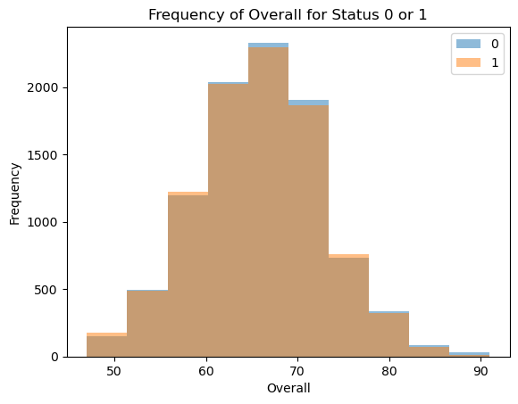

```python
# Write your own code

for status in list_status:
    temporarydataframe = soccer.query("status == @status")
    plt.hist(temporarydataframe["Overall"], alpha = 0.5)

plt.xlabel("Overall")
plt.ylabel("Frequency")
plt.title("Frequency of Overall for Status 0 or 1")
plt.legend(labels = list_status)
```